# Analyzing Individual BGG Users

Phil Henrickson

2022-01-02

# **transplant83’s** BoardGameGeek Collection

This notebook contains a set of analyses for the selected user’s boardgamegeek collection. The bulk of the analysis is focused on building a user-specific predictive model to predict the games that transplant83 is likely to own. This enables to ask questions like, based on the games the user currently owns, what games are a good fit for their collection? What upcoming games are they likely to purchase?

This analysis is based on data from BoardGameGeek that was last updated on **2021-12-20.**

# 1 Collection Overview

We can look at a basic description of the number of games that the user owns, has rated, has previously owned, etc.

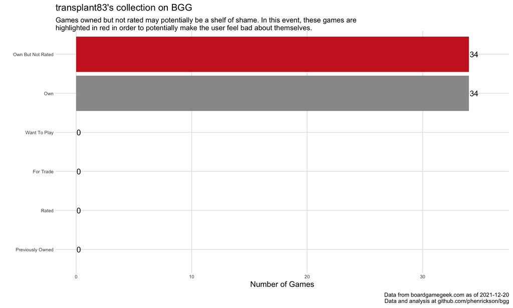

What years has the user owned/rated games from? While we can’t see when a user added or removed a game from their collection, we can look at their collection by the years in which their games were published.

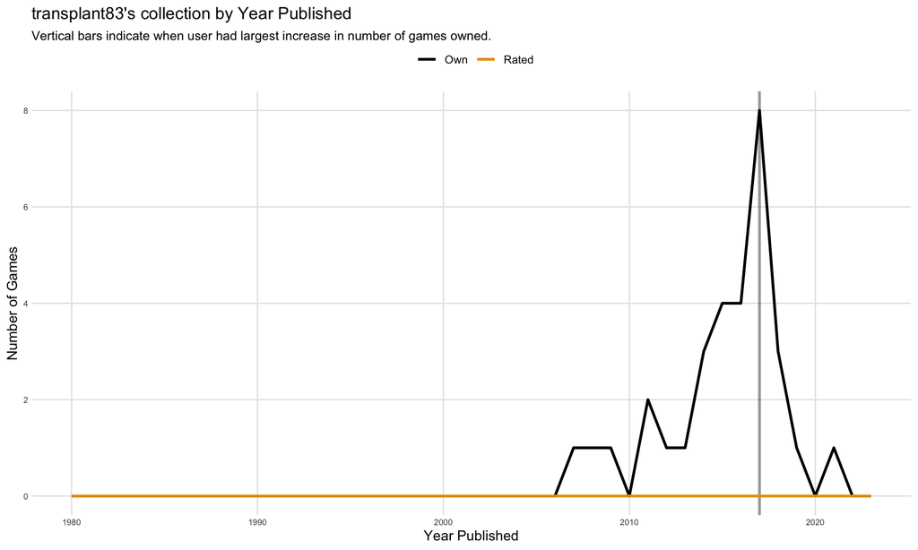

## 1.1 What types of games does transplant83 own?

We can look at the most frequent types of categories, mechanics, designers, and artists that appear in a user’s collection.

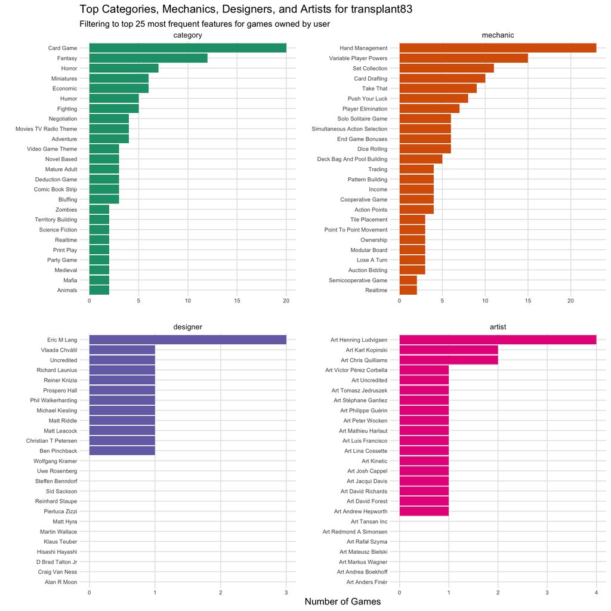

# 2 Modeling **transplant83’s** Collection

| username | dataset | period | games_owned | games_rated | games_played |
| --- | --- | --- | --- | --- | --- |
| transplant83 | training | published before 2018 | 29 | 0 | 29 |
| transplant83 | test | published 2018 or later | 5 | 0 | 5 |

There are two main (binary) outcomes we will be modeling for the user.

The first, **own** refers to whether the user currently lists a game as owned in their collection. The second, **played** refers to whether the user currently owns, has rated, or previously owned a game. This means the latter will generally have a larger list of games, but may still be a useful category to examine for people who play lots of games without necessarily owning them.

We will train predictive models to learn the probability that the user will own or play individual games based on their features.

## 2.1 Coefficients for transplant83

We can examine coefficients from the trained modes, which are penalized logistic regressions fit to our two main outcomes. Positive values indicate that a feature increases a user’s probabilility of owning/rating a game, while negative values indicate a feature decreases the probability.

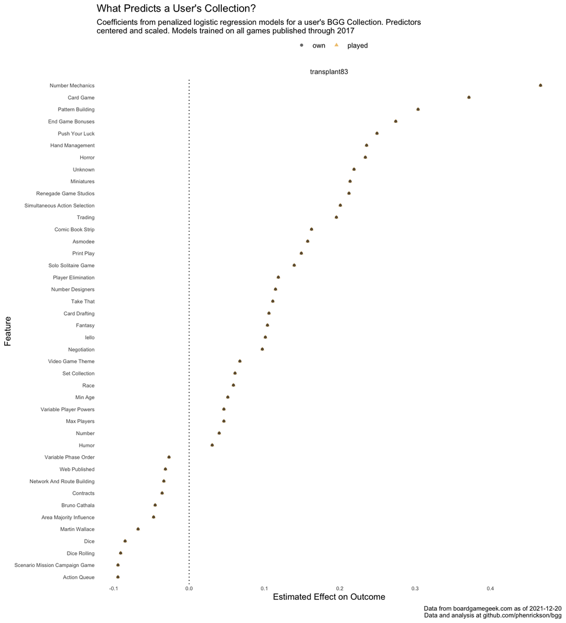

## 2.2 Visualizing Predictors for transplant83’s Collection

Why did the model identify these features? We can make density plots of the important features for predicting whether the user owned a game. Blue indicates the density for games owned by the user, while grey indicates the density for games not owned by the user.

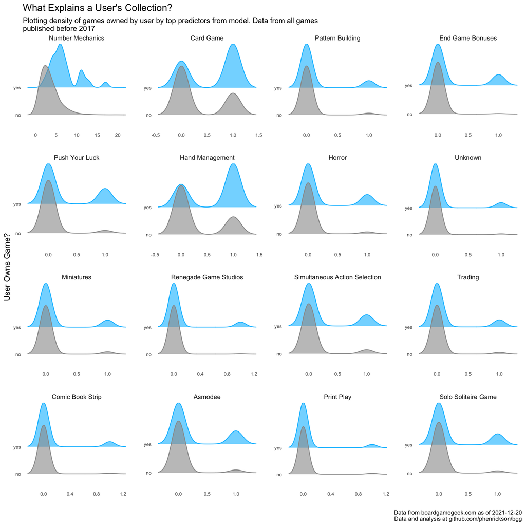

Binary predictors can be difficult to see with this visualization, so we can also directly examine the percentage of games in a user’s collection with a predictor vs the percentage of all games with that predictor.

| username | Feature | % of Games with Feature In_Collection | % of Games with Feature All_Games | Ratio |
| --- | --- | --- | --- | --- |
| transplant83 | End Game Bonuses | 20.7% | 0.9% | 23.2 |
| transplant83 | Renegade Game Studios | 10.3% | 0.6% | 16.5 |
| transplant83 | Comic Book Strip | 10.3% | 1.3% | 8.2 |
| transplant83 | Unknown | 10.3% | 1.7% | 6.1 |
| transplant83 | Player Elimination | 24.1% | 4.1% | 5.9 |
| transplant83 | Horror | 20.7% | 3.6% | 5.7 |
| transplant83 | Push Your Luck | 27.6% | 4.9% | 5.6 |
| transplant83 | Solo Solitaire Game | 20.7% | 4.2% | 4.9 |
| transplant83 | Asmodee | 24.1% | 5.2% | 4.7 |
| transplant83 | Take That | 27.6% | 5.9% | 4.7 |
| transplant83 | Trading | 13.8% | 3.4% | 4.0 |
| transplant83 | Pattern Building | 13.8% | 3.6% | 3.8 |
| transplant83 | Print Play | 6.9% | 2.0% | 3.5 |
| transplant83 | Iello | 10.3% | 3.0% | 3.5 |
| transplant83 | Negotiation | 13.8% | 3.9% | 3.5 |
| transplant83 | Card Drafting | 34.5% | 11.3% | 3.1 |
| transplant83 | Miniatures | 13.8% | 4.6% | 3.0 |
| transplant83 | Simultaneous Action Selection | 20.7% | 7.4% | 2.8 |
| transplant83 | Hand Management | 65.5% | 26.5% | 2.5 |
| transplant83 | Fantasy | 31.0% | 13.8% | 2.2 |
| transplant83 | Card Game | 62.1% | 30.9% | 2.0 |
| transplant83 | Dice Rolling | 17.2% | 28.8% | 0.6 |
| transplant83 | Action Queue | 0.0% | 2.3% | 0.0 |
| transplant83 | Scenario Mission Campaign Game | 0.0% | 2.3% | 0.0 |
| transplant83 | Dice | 0.0% | 8.0% | 0.0 |

# 3 Assess Model’s Performance on Training Set

Before predicting games in upcoming years, we can examine how well the model did and what games it liked in the training set. In this case, we used resampling techniques (cross validation) to ensure that the model had not seen a game before making its predictions.

## 3.1 Separation Plot

An easy way to examine the performance of classification model is to view a separation plot. We plot the predicted probabilities from the model for every game (from resampling) from lowest to highest. We then overlay a blue line for any game that the user does own. A good classifier is one that is able to *separate* the blue (games owned by the user) from the white (games not owned by the user), with most of the blue occurring at the highest probabilities (right side of the chart).

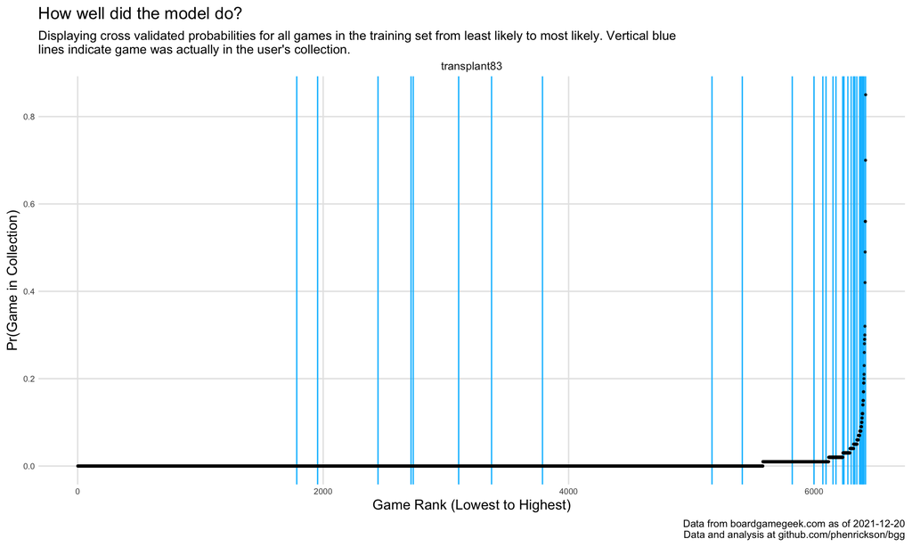

## 3.2 Top Games for **transplant83** from Training Set

We can display this information in table form, displaying the 100 games with the highest probability of ownership, adding a blue line when the user does own the game.

| username | yearpublished | game_id | name | pred_played | pred_own | actual_played | actual_own |
| --- | --- | --- | --- | --- | --- | --- | --- |
| transplant83 | 2016 | 176083 | Hit Z Road | 0.85 | 0.85 | 0 | 0 |
| transplant83 | 2016 | 201808 | Clank!: A Deck-Building Adventure | 0.70 | 0.70 | 1 | 1 |
| transplant83 | 2013 | 52461 | Legacy: The Testament of Duke de Crecy | 0.56 | 0.56 | 0 | 0 |
| transplant83 | 2013 | 124548 | The Doom That Came to Atlantic City | 0.56 | 0.56 | 0 | 0 |
| transplant83 | 2015 | 171273 | FUSE | 0.49 | 0.49 | 0 | 0 |
| transplant83 | 2016 | 192291 | Sushi Go Party! | 0.42 | 0.42 | 0 | 0 |
| transplant83 | 2017 | 256804 | Exploding Kittens: Party Pack | 0.32 | 0.32 | 0 | 0 |
| transplant83 | 2014 | 155426 | Castles of Mad King Ludwig | 0.30 | 0.30 | 0 | 0 |
| transplant83 | 2015 | 140934 | Arboretum | 0.29 | 0.29 | 0 | 0 |
| transplant83 | 2017 | 174430 | Gloomhaven | 0.29 | 0.29 | 0 | 0 |
| transplant83 | 2011 | 70919 | Takenoko | 0.28 | 0.28 | 0 | 0 |
| transplant83 | 2008 | 39463 | Cosmic Encounter | 0.26 | 0.26 | 0 | 0 |
| transplant83 | 1948 | 320 | Scrabble | 0.23 | 0.23 | 0 | 0 |
| transplant83 | 2015 | 172242 | Exploding Kittens: NSFW Deck | 0.21 | 0.21 | 1 | 1 |
| transplant83 | 2017 | 220517 | The Shipwreck Arcana | 0.20 | 0.20 | 0 | 0 |
| transplant83 | 2014 | 155703 | Evolution | 0.19 | 0.19 | 0 | 0 |
| transplant83 | 2005 | 17133 | Railways of the World | 0.19 | 0.19 | 0 | 0 |
| transplant83 | 2002 | 4174 | Lifeboat | 0.17 | 0.17 | 0 | 0 |
| transplant83 | 2005 | 18258 | Mission: Red Planet | 0.17 | 0.17 | 0 | 0 |
| transplant83 | 2013 | 146278 | Tash-Kalar: Arena of Legends | 0.15 | 0.15 | 0 | 0 |
| transplant83 | 2017 | 220308 | Gaia Project | 0.15 | 0.15 | 0 | 0 |
| transplant83 | 2017 | 217861 | Paper Tales | 0.15 | 0.15 | 0 | 0 |
| transplant83 | 2015 | 163967 | Tiny Epic Galaxies | 0.14 | 0.14 | 0 | 0 |
| transplant83 | 2016 | 195856 | Bloodborne: The Card Game | 0.14 | 0.14 | 1 | 1 |
| transplant83 | 2015 | 181687 | The Pursuit of Happiness | 0.12 | 0.12 | 0 | 0 |
| transplant83 | 2017 | 233371 | Clank! In! Space!: A Deck-Building Adventure | 0.12 | 0.12 | 0 | 0 |
| transplant83 | 2013 | 142992 | Gravwell: Escape from the 9th Dimension | 0.12 | 0.12 | 0 | 0 |
| transplant83 | 2012 | 113924 | Zombicide | 0.12 | 0.12 | 0 | 0 |
| transplant83 | 2005 | 14996 | Ticket to Ride: Europe | 0.12 | 0.12 | 0 | 0 |
| transplant83 | 2015 | 180593 | The Bloody Inn | 0.11 | 0.11 | 1 | 1 |

[output cut: 70 more lines]

We can also more formally assess how well the model did in resampling by looking at the area under the receiver operating characteristic. A perfect model would receive a score of 1, while a model that cannot predict the outcome will default to a score of 0.5. The extent to which something is a *good* score depends on the setting, but generally anything in the .8 to .9 range is very good while the .7 to .8 range is perfectly acceptable.

| username | outcome_type | .metric | .estimator | .estimate |
| --- | --- | --- | --- | --- |
| transplant83 | own | roc_auc | binary | 0.89 |
| transplant83 | played | roc_auc | binary | 0.89 |

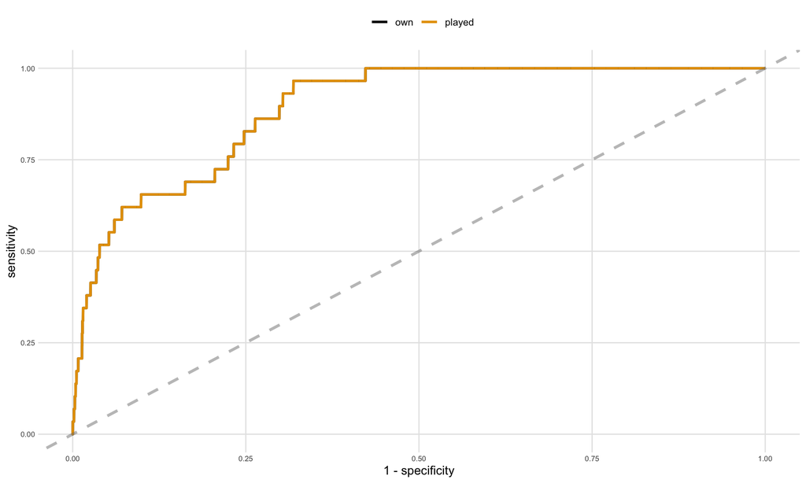

Another way to think about the model performance is to view its lift, or its ability to detect the positive outcomes over that of a null model. High lift indicates the model can much more quickly find all of the positive outcomes (in this case, games owned or played by the user), while a model with no lift is no better than random guessing.

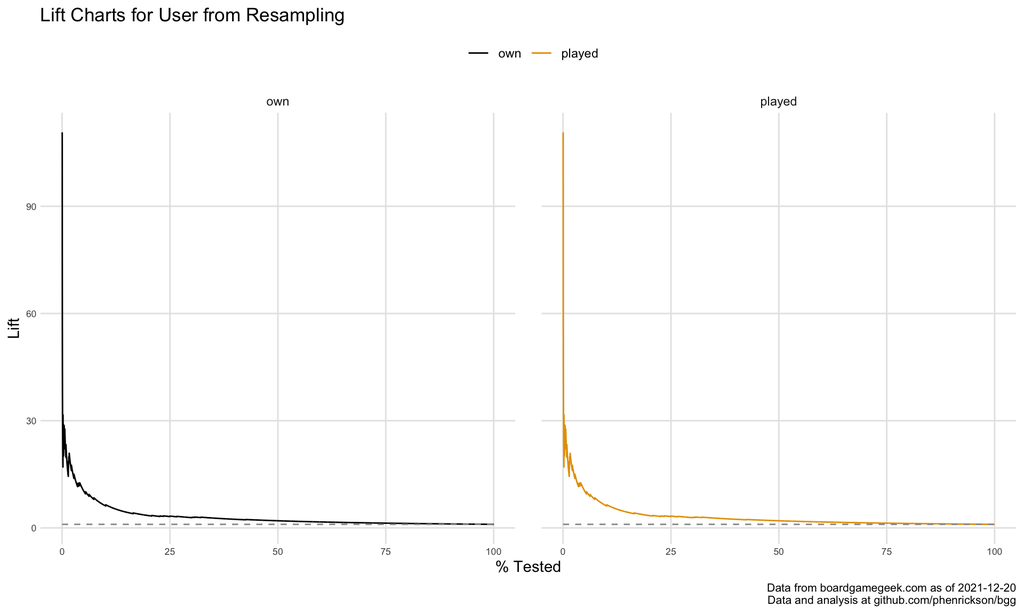

## 3.3 Most and Least Likely Games

What games does the model think transplant83 is **most likely to own** that are **not** in their collection?

| username | yearpublished | game_id | name | pred_own | actual_own |
| --- | --- | --- | --- | --- | --- |
| transplant83 | 2016 | 176083 | Hit Z Road | 0.85 | 0 |
| transplant83 | 2013 | 52461 | Legacy: The Testament of Duke de Crecy | 0.56 | 0 |
| transplant83 | 2013 | 124548 | The Doom That Came to Atlantic City | 0.56 | 0 |
| transplant83 | 2015 | 171273 | FUSE | 0.49 | 0 |
| transplant83 | 2016 | 192291 | Sushi Go Party! | 0.42 | 0 |

What games does the model think transplant83 is **least likely to own** that **are** in their collection?

| username | yearpublished | game_id | name | pred_own | actual_own |
| --- | --- | --- | --- | --- | --- |
| transplant83 | 2008 | 30549 | Pandemic | 0 | 1 |
| transplant83 | 2014 | 89910 | Run, Fight, or Die! | 0 | 1 |
| transplant83 | 2017 | 197831 | Dark Souls: The Board Game | 0 | 1 |
| transplant83 | 1960 | 148203 | Dutch Blitz | 0 | 1 |
| transplant83 | 2012 | 178494 | Dutch Blitz: Blue Expansion Pack | 0 | 1 |

## 3.4 Top Games by Year

Top 25 games most likely to be owned by the user in each year, highlighting in blue the games that the user has owned/played.

| rank | 2009 | 2010 | 2011 | 2012 | 2013 | 2014 | 2015 | 2016 | 2017 |
| --- | --- | --- | --- | --- | --- | --- | --- | --- | --- |
| 1 | The Werewolves of Miller's Hollow: The Village | Troyes | Takenoko | Zombicide | Legacy: The Testament of Duke de Crecy | Castles of Mad King Ludwig | FUSE | Hit Z Road | Exploding Kittens: Party Pack |
| 2 | Shipyard | Forbidden Island | Munchkin Axe Cop | Penny Arcade: The Game – Rumble in R'lyeh | The Doom That Came to Atlantic City | Evolution | Arboretum | Clank!: A Deck-Building Adventure | Gloomhaven |
| 3 | Arcana | Dominant Species | Nightfall | Keyflower | Tash-Kalar: Arena of Legends | Alchemists | Exploding Kittens: NSFW Deck | Sushi Go Party! | The Shipwreck Arcana |
| 4 | Luna Llena: Full Moon | Escape from the Aliens in Outer Space | Gears of War: The Board Game | Coup | Gravwell: Escape from the 9th Dimension | Sheriff of Nottingham | Tiny Epic Galaxies | Bloodborne: The Card Game | Gaia Project |
| 5 | Deadlands: The Battle for Slaughter Gulch | Dungeons & Dragons: Castle Ravenloft Board Game | Trajan | Targi | The Ravens of Thri Sahashri | Five Tribes | The Pursuit of Happiness | The Blood of an Englishman | Paper Tales |
| 6 | Jaipur | Asteroyds | Sentinels of the Multiverse | Tzolk'in: The Mayan Calendar | Sushi Go! | Smash Up: Science Fiction Double Feature | The Bloody Inn | Perdition's Mouth: Abyssal Rift | Clank! In! Space!: A Deck-Building Adventure |
| 7 | Ra: The Dice Game | Earth Reborn | Mundus Novus | Wiz-War (Eighth Edition) | Smash Up: Awesome Level 9000 | Spurs: A Tale in the Old West | Grand Austria Hotel | Dicey Goblins | Bargain Quest |
| 8 | Wings of War: WW2 Deluxe set | Sid Meier's Civilization: The Board Game | Nightfall: Martial Law | Kairo | Patchistory | King of New York | Blood Rage | Dead of Winter: The Long Night | This War of Mine: The Board Game |
| 9 | Kraby | Leaping Lemmings | Friday | Terra Mystica | Tomorrow | Shipwrights of the North Sea | Dale of Merchants | 13 Days: The Cuban Missile Crisis | Bears vs Babies |
| 10 | Chaos in the Old World | Labyrinth: The War on Terror, 2001 – ? | Pastiche | Suburbia | Forbidden Desert | Star Realms | Zombicide Season 3: Rue Morgue | Mr. Cabbagehead's Garden | Zombie Tsunami |
| 11 | Nanuk | Warhammer: The Island of Blood | Penny Arcade: The Game – Gamers vs. Evil | Santa Cruz | Firefly: The Game | Ultimate Werewolf: Deluxe Edition | Exploding Kittens | Islebound | Codenames: Duet |
| 12 | Poo: The Card Game | Warhammer: The Game of Fantasy Battles (8th Edition) | The Walking Dead: The Board Game | Fish Cook | Two Rooms and a Boom | Marrying Mr. Darcy | Dragon Racer | Avenue | Endangered Orphans of Condyle Cove |
| 13 | The Adventurers: The Temple of Chac | Zombie Dice | Nile DeLuxor | Pax Porfiriana | Room 25 | Legendary Encounters: An Alien Deck Building Game | Super Dungeon Explore: Forgotten King | Shiba Inu House | Itchy Feet: the Travel Game |
| 14 | All Things Zombie: The Boardgame | Defenders of the Realm | Rolling Stock | The Resistance: Avalon | Lewis & Clark: The Expedition | Hawken: Real-Time Card Game | The Big Book of Madness | Kanagawa | Fate of the Elder Gods |
| 15 | Hansa Teutonica | 51st State | Yomi | Legendary: A Marvel Deck Building Game | Hanamikoji | Abyss | March of the Ants | The Networks | Escape the Dark Castle |
| 16 | Cyclades | Key Market | Ascension: Return of the Fallen | Nightfall: The Coldest War | Boss Monster: The Dungeon Building Card Game | Viceroy | BattleCON: Fate of Indines | Terraforming Mars | Breaking Bad: The Board Game |
| 17 | Ratuki | Zombie Survival: The Board Game | Feudalia | Spartacus: A Game of Blood and Treachery | Zombicide Season 2: Prison Outbreak | DungeonQuest Revised Edition | Bottom of the 9th | Covert | Summit: The Board Game |
| 18 | Name 5 | Merchants & Marauders | Discworld: Ankh-Morpork | Il Vecchio | Impulse | Dragon's Hoard | Brick Party | Pandemic: Reign of Cthulhu | Truck Off: The Food Truck Frenzy |
| 19 | Waterloo | Innovation | Mage Knight Board Game | IOTA | Funemployed | Galaxy of Trian | Haspelknecht | Lotus | Folklore: The Affliction |
| 20 | The Caucasus Campaign | BattleCON: War of Indines | Resident Evil Deck Building Game: Alliance | Android: Infiltration | Circus Train (Second Edition) | Ca$h 'n Guns (Second Edition) | Kingdom Death: Monster | The Oregon Trail Card Game | The Fox in the Forest |
| 21 | Grind | Asara | Terra Evolution | Space Cadets | Dungeon Command: Blood of Gruumsh | Student Bodies | X-Men: Mutant Revolution | Black Orchestra | Arkham Noir: Case #1 – The Witch Cult Murders |
| 22 | Dungeon Twister 2: Prison | Ascension: Deckbuilding Game | Ascension: Storm of Souls | Archipelago | Sedition Wars: Battle for Alabaster | Belle of the Ball | Pandemic Legacy: Season 1 | Mansions of Madness: Second Edition | Raxxon |
| 23 | Space Hulk (Third Edition) | Resident Evil Deck Building Game | Tetris Link | Descent: Journeys in the Dark (Second Edition) | Smash Up: The Obligatory Cthulhu Set | Heroes Wanted | Baseball Highlights: 2045 | Virulence: An Infectious Card Game | Ex Libris |
| 24 | Hellenes: Campaigns of the Peloponnesian War | Puzzle Strike | Elder Sign | Mage Wars Arena | Batman: Arkham City Escape | Strife: Legacy of the Eternals | Best Treehouse Ever | Behind the Throne | Fireworks |
| 25 | The Halls of Montezuma | Big Five | Killer Bunnies and the Conquest of the Magic Carrot | Dungeon Command: Sting of Lolth | Rivet Wars: Eastern Front | Draco Magi | Between Two Cities | Dale of Merchants 2 | Super Mario Bros. Power Up Card Game |

## 3.5 Interactive Predictions from Resampling

Interactive table for predictions from resampling.

|  | username | yearpublished | rank | game_id | name | pred_played | pred_own | actual_played | actual_own |
| --- | --- | --- | --- | --- | --- | --- | --- | --- | --- |
| 1 | transplant83 | 1900 | 173 | 10799 | Old Maid | 0.03 | 0.03 | 0 | 0 |
| 2 | transplant83 | 1900 | 175 | 2394 | Dominoes | 0.03 | 0.03 | 0 | 0 |
| 3 | transplant83 | 1900 | 272 | 1115 | Poker | 0.02 | 0.02 | 0 | 0 |
| 4 | transplant83 | 1900 | 370 | 10400 | Patience | 0.01 | 0.01 | 0 | 0 |
| 5 | transplant83 | 1900 | 376 | 7316 | Bingo | 0.01 | 0.01 | 0 | 0 |
| 6 | transplant83 | 1900 | 443 | 2173 | 4 Player Chess | 0.01 | 0.01 | 0 | 0 |
| 7 | transplant83 | 1900 | 475 | 21389 | Happy Families | 0.01 | 0.01 | 0 | 0 |
| 8 | transplant83 | 1900 | 595 | 17003 | Snap | 0.01 | 0.01 | 0 | 0 |
| 9 | transplant83 | 1900 | 598 | 5451 | Hanafuda | 0.01 | 0.01 | 0 | 0 |
| 10 | transplant83 | 1900 | 635 | 15878 | Rummy | 0.01 | 0.01 | 0 | 0 |

[output cut: 6410 more lines]

# 4 Validating the Model on 2018

How well did a model trained on a user’s collection through 2017 perform in predicting games for the user from 2018?

| username | outcome_type | yearpublished | .metric | .estimator | .estimate |
| --- | --- | --- | --- | --- | --- |
| transplant83 | own | 2018 | roc_auc | binary | 0.713 |
| transplant83 | played | 2018 | roc_auc | binary | 0.713 |

Table of top 25 games from 2018, highlighting games that the user owns.

| username | yearpublished | game_id | name | pred_own | pred_played | actual_own | actual_played |
| --- | --- | --- | --- | --- | --- | --- | --- |
| transplant83 | 2018 | 205896 | Rising Sun | 0.84 | 0.84 | 0 | 0 |
| transplant83 | 2018 | 244711 | Newton | 0.21 | 0.21 | 0 | 0 |
| transplant83 | 2018 | 256226 | Azul: Stained Glass of Sintra | 0.19 | 0.19 | 0 | 0 |
| transplant83 | 2018 | 199792 | Everdell | 0.18 | 0.18 | 0 | 0 |
| transplant83 | 2018 | 313010 | Cosmic Encounter: 42nd Anniversary Edition | 0.15 | 0.15 | 0 | 0 |
| transplant83 | 2018 | 258444 | Gingerbread House | 0.11 | 0.11 | 0 | 0 |
| transplant83 | 2018 | 222219 | Kero | 0.09 | 0.09 | 0 | 0 |
| transplant83 | 2018 | 247763 | Underwater Cities | 0.09 | 0.09 | 0 | 0 |
| transplant83 | 2018 | 232405 | Western Legends | 0.08 | 0.08 | 0 | 0 |
| transplant83 | 2018 | 245928 | Pax Emancipation | 0.07 | 0.07 | 0 | 0 |
| transplant83 | 2018 | 269618 | Crystallo | 0.07 | 0.07 | 0 | 0 |
| transplant83 | 2018 | 167355 | Nemesis | 0.06 | 0.06 | 0 | 0 |
| transplant83 | 2018 | 236709 | The Tea Dragon Society Card Game | 0.06 | 0.06 | 0 | 0 |
| transplant83 | 2018 | 237174 | So Long, My World | 0.05 | 0.05 | 0 | 0 |
| transplant83 | 2018 | 240196 | Betrayal Legacy | 0.05 | 0.05 | 0 | 0 |
| transplant83 | 2018 | 119881 | Medioevo Universale | 0.04 | 0.04 | 0 | 0 |
| transplant83 | 2018 | 171964 | The Order of Vampire Hunters | 0.04 | 0.04 | 0 | 0 |
| transplant83 | 2018 | 218421 | Street Masters | 0.04 | 0.04 | 0 | 0 |
| transplant83 | 2018 | 222145 | Lucidity: Six-Sided Nightmares | 0.04 | 0.04 | 0 | 0 |
| transplant83 | 2018 | 225885 | Unbroken | 0.04 | 0.04 | 0 | 0 |
| transplant83 | 2018 | 239464 | Palm Island | 0.04 | 0.04 | 0 | 0 |
| transplant83 | 2018 | 260332 | Hokkaido | 0.04 | 0.04 | 0 | 0 |
| transplant83 | 2018 | 170604 | Renegade | 0.03 | 0.03 | 0 | 0 |
| transplant83 | 2018 | 222509 | Lords of Hellas | 0.03 | 0.03 | 0 | 0 |
| transplant83 | 2018 | 230253 | Star Realms: Frontiers | 0.03 | 0.03 | 0 | 0 |

# 5 Predicting Upcoming Games (2018 and On) for **transplant83**

Examine the top games for the test set.

| username | yearpublished | game_id | name | rank | own | played |
| --- | --- | --- | --- | --- | --- | --- |
| transplant83 | 2018 | 205896 | Rising Sun | 1 | 0.84 | 0.84 |
| transplant83 | 2018 | 244711 | Newton | 2 | 0.21 | 0.21 |
| transplant83 | 2018 | 256226 | Azul: Stained Glass of Sintra | 3 | 0.19 | 0.19 |
| transplant83 | 2018 | 199792 | Everdell | 4 | 0.18 | 0.18 |
| transplant83 | 2018 | 313010 | Cosmic Encounter: 42nd Anniversary Edition | 5 | 0.15 | 0.15 |
| transplant83 | 2018 | 258444 | Gingerbread House | 6 | 0.11 | 0.11 |
| transplant83 | 2018 | 222219 | Kero | 7 | 0.09 | 0.09 |
| transplant83 | 2018 | 247763 | Underwater Cities | 8 | 0.09 | 0.09 |
| transplant83 | 2018 | 232405 | Western Legends | 9 | 0.08 | 0.08 |
| transplant83 | 2018 | 269618 | Crystallo | 10 | 0.07 | 0.07 |
| transplant83 | 2018 | 245928 | Pax Emancipation | 11 | 0.07 | 0.07 |
| transplant83 | 2018 | 167355 | Nemesis | 12 | 0.06 | 0.06 |
| transplant83 | 2018 | 236709 | The Tea Dragon Society Card Game | 13 | 0.06 | 0.06 |
| transplant83 | 2018 | 240196 | Betrayal Legacy | 14 | 0.05 | 0.05 |
| transplant83 | 2018 | 237174 | So Long, My World | 15 | 0.05 | 0.05 |
| transplant83 | 2018 | 225885 | Unbroken | 16 | 0.04 | 0.04 |
| transplant83 | 2018 | 239464 | Palm Island | 17 | 0.04 | 0.04 |
| transplant83 | 2018 | 119881 | Medioevo Universale | 18 | 0.04 | 0.04 |
| transplant83 | 2018 | 171964 | The Order of Vampire Hunters | 19 | 0.04 | 0.04 |
| transplant83 | 2018 | 218421 | Street Masters | 20 | 0.04 | 0.04 |
| transplant83 | 2018 | 260332 | Hokkaido | 21 | 0.04 | 0.04 |
| transplant83 | 2018 | 222145 | Lucidity: Six-Sided Nightmares | 22 | 0.04 | 0.04 |
| transplant83 | 2018 | 257839 | Arkham Noir: Case #2 – Called Forth By Thunder | 23 | 0.03 | 0.03 |
| transplant83 | 2018 | 246855 | Boss Monster: Rise of the Minibosses | 24 | 0.03 | 0.03 |
| transplant83 | 2018 | 244536 | Tiny Epic Zombies | 25 | 0.03 | 0.03 |
| transplant83 | 2019 | 266507 | Clank!: Legacy – Acquisitions Incorporated | 1 | 0.97 | 0.97 |
| transplant83 | 2019 | 270971 | Era: Medieval Age | 2 | 0.52 | 0.52 |
| transplant83 | 2019 | 265736 | Tiny Towns | 3 | 0.40 | 0.40 |
| transplant83 | 2019 | 271324 | It's a Wonderful World | 4 | 0.40 | 0.40 |
| transplant83 | 2019 | 257066 | Sierra West | 5 | 0.24 | 0.24 |
| transplant83 | 2019 | 253574 | Crusader Kings | 6 | 0.18 | 0.18 |
| transplant83 | 2019 | 266192 | Wingspan | 7 | 0.14 | 0.14 |
| transplant83 | 2019 | 264982 | Coloma | 8 | 0.12 | 0.12 |
| transplant83 | 2019 | 276025 | Maracaibo | 9 | 0.11 | 0.11 |
| transplant83 | 2019 | 283863 | The Magnificent | 10 | 0.11 | 0.11 |
| transplant83 | 2019 | 260710 | Amul | 11 | 0.09 | 0.09 |
| transplant83 | 2019 | 287954 | Azul: Summer Pavilion | 12 | 0.09 | 0.09 |
| transplant83 | 2019 | 252163 | Shardhunters | 13 | 0.07 | 0.07 |
| transplant83 | 2019 | 274637 | Unmatched: Battle of Legends, Volume One | 14 | 0.07 | 0.07 |
| transplant83 | 2019 | 274638 | Unmatched: Robin Hood vs. Bigfoot | 15 | 0.06 | 0.06 |
| transplant83 | 2019 | 264220 | Tainted Grail: The Fall of Avalon | 16 | 0.06 | 0.06 |
| transplant83 | 2019 | 257096 | Run Fight or Die: Reloaded | 17 | 0.05 | 0.05 |
| transplant83 | 2019 | 285774 | Marvel Champions: The Card Game | 18 | 0.05 | 0.05 |
| transplant83 | 2019 | 269144 | Hadara | 19 | 0.04 | 0.04 |
| transplant83 | 2019 | 267304 | Western Empires | 20 | 0.04 | 0.04 |
| transplant83 | 2019 | 295564 | Unmatched Game System | 21 | 0.04 | 0.04 |
| transplant83 | 2019 | 251349 | Miskatonic University: The Restricted Collection | 22 | 0.04 | 0.04 |
| transplant83 | 2019 | 251247 | Barrage | 23 | 0.04 | 0.04 |
| transplant83 | 2019 | 281259 | The Isle of Cats | 24 | 0.04 | 0.04 |
| transplant83 | 2019 | 244820 | Posthuman Saga | 25 | 0.03 | 0.03 |
| transplant83 | 2020 | 296151 | Viscounts of the West Kingdom | 1 | 0.59 | 0.59 |
| transplant83 | 2020 | 256317 | Guild Master | 2 | 0.58 | 0.58 |
| transplant83 | 2020 | 293556 | Gloomy Graves | 3 | 0.43 | 0.43 |
| transplant83 | 2020 | 307844 | Atheneum: Mystic Library | 4 | 0.28 | 0.28 |
| transplant83 | 2020 | 294484 | Unmatched: Cobble & Fog | 5 | 0.25 | 0.25 |
| transplant83 | 2020 | 279537 | The Search for Planet X | 6 | 0.25 | 0.25 |
| transplant83 | 2020 | 302310 | Nanaki | 7 | 0.21 | 0.21 |
| transplant83 | 2020 | 236861 | Full Moon Jacket | 8 | 0.18 | 0.18 |
| transplant83 | 2020 | 184267 | On Mars | 9 | 0.17 | 0.17 |
| transplant83 | 2020 | 313698 | Monster Expedition | 10 | 0.14 | 0.14 |
| transplant83 | 2020 | 291457 | Gloomhaven: Jaws of the Lion | 11 | 0.13 | 0.13 |
| transplant83 | 2020 | 302840 | Carcata | 12 | 0.13 | 0.13 |
| transplant83 | 2020 | 310885 | Belaad: The Land of Swords and Quills | 13 | 0.10 | 0.10 |
| transplant83 | 2020 | 298371 | Wild Space | 14 | 0.08 | 0.08 |
| transplant83 | 2020 | 295905 | Cosmic Frog | 15 | 0.07 | 0.07 |
| transplant83 | 2020 | 299074 | Space Battle Lunchtime Card Game | 16 | 0.07 | 0.07 |
| transplant83 | 2020 | 325635 | Unmatched: Little Red Riding Hood vs. Beowulf | 17 | 0.07 | 0.07 |
| transplant83 | 2020 | 300322 | Hallertau | 18 | 0.07 | 0.07 |
| transplant83 | 2020 | 272533 | Kingdom Rush: Rift in Time | 19 | 0.06 | 0.06 |
| transplant83 | 2020 | 253506 | Versailles 1919 | 20 | 0.06 | 0.06 |
| transplant83 | 2020 | 293678 | Stellar | 21 | 0.05 | 0.05 |
| transplant83 | 2020 | 259061 | Skytear | 22 | 0.05 | 0.05 |
| transplant83 | 2020 | 304434 | Victim: The Cursed Forest | 23 | 0.05 | 0.05 |
| transplant83 | 2020 | 320819 | Dinner in Paris | 24 | 0.04 | 0.04 |
| transplant83 | 2020 | 284777 | Unmatched: Jurassic Park – InGen vs Raptors | 25 | 0.04 | 0.04 |

## 5.1 Interactive Table for Upcoming Games 2018 and On

|  | username | yearpublished | game_id | name | rank | own | played |
| --- | --- | --- | --- | --- | --- | --- | --- |
| 1 | transplant83 | 2019 | 266507 | Clank!: Legacy – Acquisitions Incorporated | 1 | 0.97 | 0.97 |
| 2 | transplant83 | 2018 | 205896 | Rising Sun | 2 | 0.84 | 0.84 |
| 3 | transplant83 | 2020 | 296151 | Viscounts of the West Kingdom | 3 | 0.59 | 0.59 |
| 4 | transplant83 | 2020 | 256317 | Guild Master | 4 | 0.58 | 0.58 |
| 5 | transplant83 | 2019 | 270971 | Era: Medieval Age | 5 | 0.52 | 0.52 |
| 6 | transplant83 | 2020 | 293556 | Gloomy Graves | 6 | 0.43 | 0.43 |
| 7 | transplant83 | 2019 | 265736 | Tiny Towns | 7 | 0.4 | 0.4 |
| 8 | transplant83 | 2019 | 271324 | It's a Wonderful World | 8 | 0.4 | 0.4 |
| 9 | transplant83 | 2020 | 307844 | Atheneum: Mystic Library | 9 | 0.28 | 0.28 |
| 10 | transplant83 | 2020 | 294484 | Unmatched: Cobble &amp; Fog | 10 | 0.25 | 0.25 |

[output cut: 1923 more lines]